# Trading and investment account summary

# For 2020-08-28

Summary text: The equity value of my live trading portfolio changed by 1.07 % (US$ 377.61 ) from US$ 35274.08 to US$ 35651.69 today ( 2020-08-28 ). The trading proceeds in my live account were US$ 128.42 . The book proceeds in my portfolio changed from US$ 2120.39 to US$ 2369.58

## Portfolio

The below table shows the current positions in the live account as well as their current and total performance. “book_proceed” indicates the unrealized profit in that position.

| symbol | close | closePerc | Total_Change_close | entry_price | position | position_size | entry_position | totalPerc | book_proceed | sector |
| --- | --- | --- | --- | --- | --- | --- | --- | --- | --- | --- |
| KWEB | 71.81 | 1.23 | 87 | 71.13 | 100 | 7181.00 | 7113.44 | 0.94 | 67.56 | Miscellaneous |
| BRK.B | 218.55 | 0.77 | 41.5 | 195.40 | 25 | 5463.75 | 4885.08 | 10.59 | 578.67 | Finance |
| SEAS | 21.36 | 3.89 | -168 | 19.05 | -210 | -4485.60 | -4000.51 | -10.81 | -485.09 | Consumer Services |
| EZA | 38.84 | 1.92 | -54.75 | 38.54 | -75 | -2913.00 | -2890.50 | -0.77 | -22.5 | Miscellaneous |
| CAKE | 30.79 | 8.34 | 208.56 | 23.83 | 88 | 2709.52 | 2097.05 | 22.6 | 612.47 | Consumer Services |
| SQ | 155.85 | 0.15 | 3.45 | 143.24 | 15 | 2337.75 | 2148.55 | 8.09 | 189.2 | Technology Services |
| TSLA | 2213.52 | -1.17 | -26.24 | 1405.56 | 1 | 2213.52 | 1405.56 | 36.5 | 807.96 | Consumer Durables |
| INDA | 34.55 | 1.9 | 32.25 | 33.05 | 50 | 1727.50 | 1652.50 | 4.34 | 75 | Miscellaneous |
| GOOG | 1644.40 | 0.56 | 9.09 | 1599.21 | 1 | 1644.40 | 1599.21 | 2.75 | 45.19 | Technology Services |
| SLV | 25.59 | 1.68 | 21.19 | 22.90 | 50 | 1279.65 | 1144.95 | 10.53 | 134.7 | Miscellaneous |
| TPR | 14.88 | -0.13 | -1.7 | 14.96 | 85 | 1264.80 | 1271.99 | -0.57 | -7.19 | Retail Trade |
| MIK | 11.13 | 2.96 | 32 | 8.51 | 100 | 1113.00 | 851.26 | 23.52 | 261.74 | Retail Trade |
| UNM | 19.01 | 0.9 | 8.5 | 19.21 | 50 | 950.50 | 960.30 | -1.03 | -9.8 | Finance |
| RVLV | 20.11 | 1.36 | 10.26 | 18.07 | 38 | 764.18 | 686.53 | 10.16 | 77.65 | Retail Trade |
| GOLD | 29.20 | 2.17 | 15.5 | 28.06 | 25 | 730.00 | 701.56 | 3.9 | 28.44 | Non-Energy Minerals |
| CAT | 143.72 | 0.22 | 1.55 | 142.04 | 5 | 718.60 | 710.20 | 1.17 | 8.4 | Producer Manufacturing |
| SWKS | 143.62 | 2.46 | 17.25 | 131.85 | 5 | 718.10 | 659.25 | 8.2 | 58.85 | Electronic Technology |
| IAU | 18.73 | 1.69 | 11.84 | 19.00 | 38 | 711.80 | 722.00 | -1.43 | -10.19 | Miscellaneous |
| PPLT | 87.86 | 0.97 | 6.72 | 89.44 | 8 | 702.88 | 715.49 | -1.79 | -12.61 | Miscellaneous |
| EPHE | 26.60 | 0.28 | -1.88 | 25.67 | -25 | -665.00 | -641.70 | -3.5 | -23.3 | Miscellaneous |
| V | 215.66 | 2.17 | 13.74 | 194.66 | 3 | 646.98 | 583.99 | 9.74 | 62.99 | Finance |
| PALL | 207.38 | 1.14 | 6.99 | 219.68 | 3 | 622.14 | 659.04 | -5.93 | -36.9 | Miscellaneous |
| DBX | 20.72 | 2.07 | 12.6 | 20.73 | 30 | 621.60 | 621.75 | -0.02 | -0.15 | Technology Services |
| MGM | 23.87 | 4.65 | 26.5 | 21.35 | 25 | 596.75 | 533.75 | 10.56 | 63 | Consumer Services |
| ABT | 110.74 | -0.49 | -2.75 | 110.90 | 5 | 553.70 | 554.50 | -0.14 | -0.8 | Health Technology |
| UPWK | 15.04 | 2.04 | 10.8 | 14.48 | 36 | 541.44 | 521.36 | 3.71 | 20.08 | Technology Services |
| NFLX | 523.89 | -0.51 | -2.7 | 486.00 | 1 | 523.89 | 486.00 | 7.23 | 37.89 | Consumer Services |
| LMND | 58.23 | -0.26 | -1.2 | 78.07 | 8 | 465.84 | 624.57 | -34.07 | -158.73 | Finance |
| CCL | 17.21 | 6.7 | 27 | 14.54 | 25 | 430.25 | 363.50 | 15.51 | 66.75 | Consumer Services |
| ILMN | 353.99 | 0.73 | 2.56 | 346.12 | 1 | 353.99 | 346.12 | 2.22 | 7.87 | Health Technology |
| GDX | 41.98 | 3.27 | 10.64 | 43.89 | 8 | 335.84 | 351.14 | -4.56 | -15.3 | Miscellaneous |
| CRUS | 61.15 | 1.24 | 3.75 | 71.60 | 5 | 305.75 | 358.02 | -17.1 | -52.27 | Electronic Technology |

| symbol | close | closePerc | Total_Change_close | entry_price | position | position_size | entry_position | totalPerc | book_proceed | sector |
| --- | --- | --- | --- | --- | --- | --- | --- | --- | --- | --- |
| Summary | NA | NA | 362.02 | NA | 1144 | 46292.72 | NA | 5.12 | 2369.576 | NA |

[interactive chart not shown]

The performance of my live stock portfolio/trading account vs. my paper trading account and the benchmark ‘SPY’, the US large cap stock market index ETF in percent since June 09 2020.

[interactive chart not shown]

This plot shows a summary of the trading activity on that day. Above 0 is a gain, below is a loss. TRUE indicated live trading account, FALSE is paper trading. A buy side trade is a closed short sale trade and sell side trade is a closed long trade.

[interactive chart not shown]

My current portfolio sorted by sectors. The plot reads clock-wise. Positions below 0 are short positions. Clicking a slice of the pie chart directs to marketwatch.com for further information.

[interactive chart not shown]

These two plots indicate the composition of my portfolio and the change of it over the past week.

[interactive chart not shown]

The inner circle is Monday, the outer circle is Friday.

[interactive chart not shown]

The colors in this plot indicate the daily percentage change of each stock in my portfolio.

[interactive chart not shown]

I classified the stocks in my portfolio by sector. The area represents the size of the position in the portfolio. Long postions

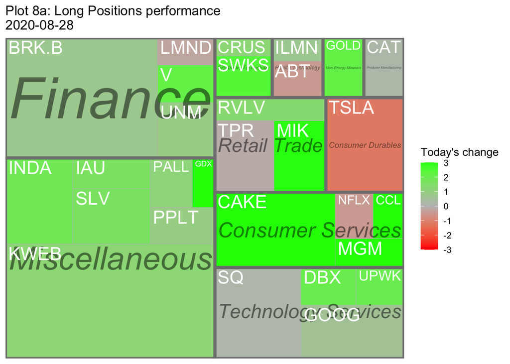

Short postions

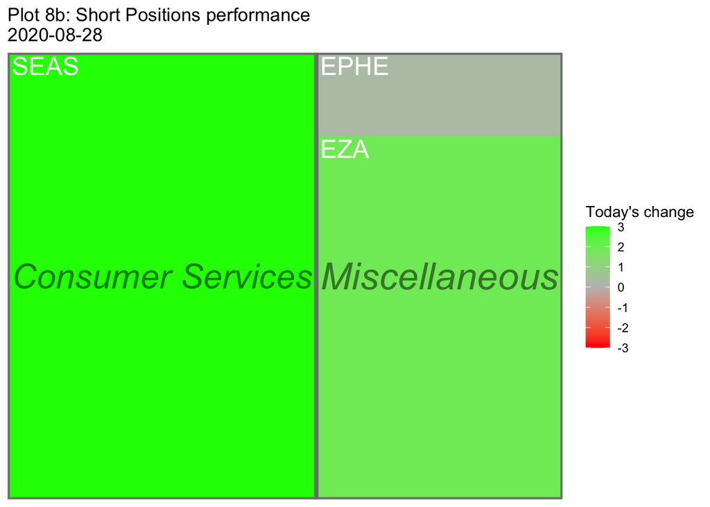

S&P 500 stocks colored by last day performance.

Outliers skew the colors, making the other stocks look pale. I restricted the colors to max of 3 and -3% change. Every stock having higher or lower than 3% change has the same color.

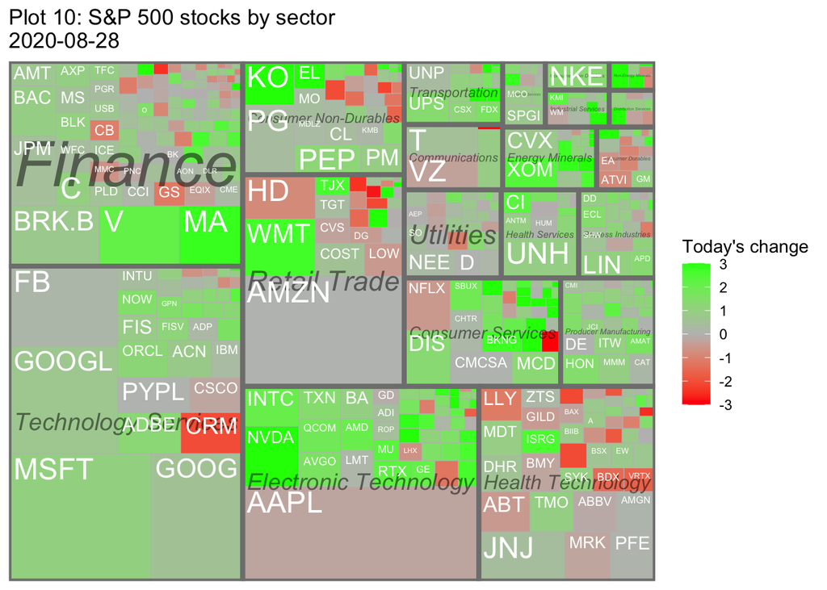

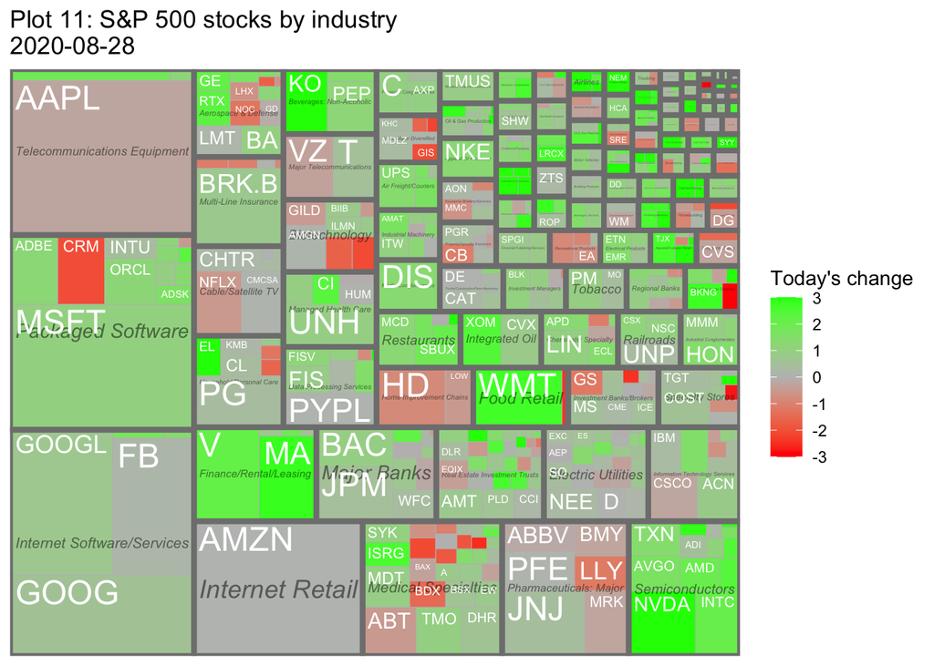